# List of Content

A. Import Libraries & Load Data

B. Data Preparation

C. The Baseline Model

D. Results

E. Important features

# A. Import Libraries and Data

```python
import pandas as pd
import seaborn as sns
import matplotlib.pyplot as plt
from sklearn.model_selection import train_test_split
from sklearn.preprocessing import StandardScaler
from imblearn.under_sampling import RandomUnderSampler
import math
import numpy as np

from sklearn import tree
from sklearn.svm import SVC

from sklearn import metrics
from sklearn.metrics import roc_curve, auc
from sklearn.metrics import classification_report, confusion_matrix, roc_auc_score, roc_curve, brier_score_loss, log_loss
from scipy.stats import levene, mannwhitneyu, shapiro, ttest_ind
from sklearn.inspection import permutation_importance
```

```python
# Loading Data
raw_data = pd.read_csv("D:/Langara/DANA4800/Team Work 7/PHASE 1 - Clean Data Set Deliver/PHASE 1 - Clean Data Set Deliver/mimic_iv_Final.csv")
raw_data.head()
```

|  | subject_id | gender | age | mortality | ethnicity | Heart.Rate | Heart.rate.Alarm...High | Heart.Rate.Alarm...Low | SpO2.Desat.Limit | INR | ... | Comb_DS | Fibrillation | PulmonaryDisease | Stroke | Hyperlipidemia | Dementia | AvgBloodPressureSystolic | AvgBloodPressureDiastolic | ConsolidatedRespiratoryRate | AvgHemoglobin |
| --- | --- | --- | --- | --- | --- | --- | --- | --- | --- | --- | --- | --- | --- | --- | --- | --- | --- | --- | --- | --- | --- |
| 0 | 10004401 | M | 82 | Death | WHITE | 104 | 120 | 60 | 100.0 | 1.7 | ... | 0 | 1 | 0 | 0 | 0 | 0 | 158.0 | 129.0 | 33.75 | 10.90 |
| 1 | 10005348 | M | 76 | Alive | WHITE | 103 | 160 | 85 | 88.0 | 1.3 | ... | 0 | 1 | 0 | 0 | 1 | 0 | 147.5 | 75.0 | 22.75 | 11.90 |
| 2 | 10010058 | M | 80 | Death | ASIAN - SOUTH EAST ASIAN | 155 | 130 | 50 | 85.0 | 1.5 | ... | 0 | 3 | 0 | 0 | 1 | 0 | 119.5 | 88.5 | 29.50 | 13.65 |
| 3 | 10013049 | M | 52 | Alive | WHITE | 91 | 120 | 50 | 85.0 | 1.6 | ... | 0 | 0 | 0 | 0 | 0 | 0 | 130.0 | 70.0 | 15.50 | 14.25 |
| 4 | 10018423 | M | 37 | Alive | WHITE | 105 | 120 | 50 | 85.0 | 1.6 | ... | 0 | 0 | 0 | 0 | 0 | 0 | 131.5 | 74.0 | 22.25 | 14.50 |

5 rows × 34 columns

```python
raw_data['mortality'].value_counts()
```

```
mortality
Alive    2916
Death     490
Name: count, dtype: int64
```

```python
# Convert Gender from Str to Numeric
raw_data['gender'] = pd.get_dummies(raw_data['gender'], drop_first = True)
raw_data['mortality'] = pd.get_dummies(raw_data['mortality'], drop_first = True)
```

```python
raw_data.columns
```

```
Index(['subject_id', 'gender', 'age', 'mortality', 'ethnicity', 'Heart.Rate',
       'Heart.rate.Alarm...High', 'Heart.Rate.Alarm...Low', 'SpO2.Desat.Limit',
       'INR', 'Prothrombin.time', 'Anion.gap', 'Creatinine..serum.',
       'Bicarbonate', 'Glucose..whole.blood.', 'GCS...Eye.Opening',
       'Hematocrit', 'Platelet.Count', 'Age.Group', 'Myocardial', 'Rupture',
       'Thrombosis', 'Systolic', 'Diastolic', 'Comb_DS', 'Fibrillation',
       'PulmonaryDisease', 'Stroke', 'Hyperlipidemia', 'Dementia',
       'AvgBloodPressureSystolic', 'AvgBloodPressureDiastolic',
       'ConsolidatedRespiratoryRate', 'AvgHemoglobin'],
      dtype='object')
```

```python
features = ['Anion.gap', 'Heart.Rate', 'Creatinine..serum.', 'ConsolidatedRespiratoryRate', 'age', 'Hematocrit', 'Bicarbonate',
            'AvgHemoglobin']
```

```python
X = raw_data[features]
y = raw_data['mortality']
```

```python
# Split dataset into training set and test set
X_train, X_test, y_train, y_test = train_test_split(X, y, test_size=0.3, random_state=123)
```

```python
# Undersampling
rus = RandomUnderSampler(random_state=42)
X_train_rus, y_train_rus= rus.fit_resample(X_train, y_train)

y_train_rus.value_counts()
```

```
mortality
False    331
True     331
Name: count, dtype: int64
```

```python
#Undersampling the test set
X_test_rus, y_test_rus= rus.fit_resample(X_test, y_test)
y_test_rus.value_counts()
```

```
mortality
False    159
True     159
Name: count, dtype: int64
```

```python
# Feature scaling
scaler = StandardScaler()
X_train_rus_scaled = scaler.fit_transform(X_train_rus)
X_test_rus_scaled = scaler.transform(X_test_rus)

# Checking the shape of the datasets
X_train_rus_scaled.shape, X_test_rus_scaled.shape, y_train_rus.shape, y_test_rus.shape
```

```
((662, 8), (318, 8), (662,), (318,))
```

```python
# Checking class distribution in the target variable
class_distribution = y_train_rus.value_counts(normalize=True)
class_distribution
```

```
mortality
False    0.5
True     0.5
Name: proportion, dtype: float64
```

# C. The baseline model - SVM baseline

```python
# define SVM classifier (using default parameters)
svm_classifier = SVC(random_state=123, probability=True)

# fit SVM into a data
svm_classifier.fit(X_train_rus_scaled, y_train_rus)
```

```
SVC(probability=True, random_state=123)
```

```python
# prediction using the best decision tree model obtained from GridSearchCV
y_pred = svm_classifier.predict(X_test_rus_scaled)
y_proba_rus = svm_classifier.predict_proba(X_test_rus_scaled)[:, 1]  # predicted probabilities for class 1
```

# D. Results

```python
# No Sampling Classification Reports
print("Classification Report: Baseline Model - Under Sampling")
print(classification_report(y_test_rus, y_pred, target_names = ['Survival', 'Death']))
```

```
Classification Report: Baseline Model - Under Sampling
              precision    recall  f1-score   support

    Survival       0.86      0.75      0.80       159
       Death       0.78      0.88      0.83       159

    accuracy                           0.81       318
   macro avg       0.82      0.81      0.81       318
weighted avg       0.82      0.81      0.81       318
```

```python
# Calculate the false positive rate, true positive rate, and thresholds
fpr_svm, tpr_svm, thresholds_svm = roc_curve(y_test_rus, y_proba_rus)

# Calculate the AUC for SVM
auc_svm = auc(fpr_svm, tpr_svm)
```

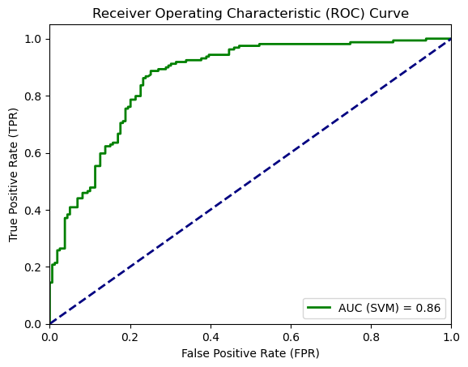

```python
# Plot ROC curve for SVM
plt.plot(fpr_svm, tpr_svm, color='green', lw=2, label=f'AUC (SVM) = {auc_svm:.2f}')

# Plot the diagonal line for reference
plt.plot([0, 1], [0, 1], color='navy', lw=2, linestyle='--')

# Set plot properties
plt.xlim([0.0, 1.0])
plt.ylim([0.0, 1.05])
plt.xlabel('False Positive Rate (FPR)')
plt.ylabel('True Positive Rate (TPR)')
plt.title('Receiver Operating Characteristic (ROC) Curve')
plt.legend(loc="lower right")

plt.show()
```

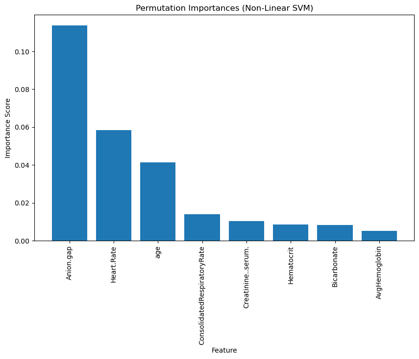

```python
# Calculate permutation importances
perm_importances = permutation_importance(svm_classifier, X_test_rus_scaled, y_test_rus, n_repeats=30, random_state=123)

# Get feature importances
feature_importances = perm_importances.importances_mean

# Create a DataFrame to associate feature names with their importances
feature_importance_df = pd.DataFrame({'Feature': X_train_rus.columns, 'Importance': feature_importances})

# Sort the DataFrame by importance in descending order
feature_importance_df = feature_importance_df.reindex(feature_importance_df['Importance'].abs().sort_values(ascending=False).index)

# Plot the feature importances
plt.figure(figsize=(10, 6))
plt.bar(range(len(feature_importance_df)), feature_importance_df['Importance'], align='center')
plt.xticks(range(len(feature_importance_df)), feature_importance_df['Feature'], rotation='vertical')
plt.xlabel('Feature')
plt.ylabel('Importance Score')
plt.title('Permutation Importances (Non-Linear SVM)')
plt.show()
```

### Error Analysis

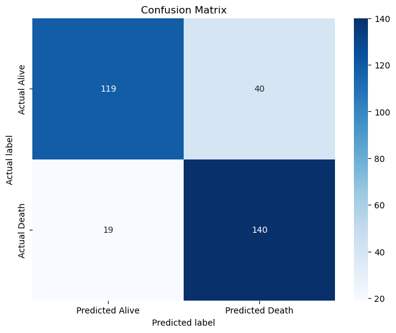

```python
# Calculate confusion matrix
conf_matrix_rus  = confusion_matrix(y_test_rus, y_pred)

# Convert confusion matrix to a DataFrame for better visualization
conf_matrix_df = pd.DataFrame(conf_matrix_rus, index=['Actual Alive', 'Actual Death'], columns=['Predicted Alive', 'Predicted Death'])

# Plot confusion matrix as a heatmap
plt.figure(figsize=(8, 6))
sns.heatmap(conf_matrix_df, annot=True, fmt='d', cmap='Blues')
plt.xlabel('Predicted label')
plt.ylabel('Actual label')
plt.title('Confusion Matrix')
plt.show()
```

1. "Actual Alive, Predicted Alive" (top-left) represents the number of cases where the model correctly predicted survival. - True Negative
2. "Actual Alive, Predicted Death" (top-right) represents the number of cases where the model incorrectly predicted death when the actual outcome was survival. - False Positive
3. "Actual Death, Predicted Alive" (bottom-left) represents the number of cases where the model incorrectly predicted survival when the actual outcome was death. - False Negative
4. "Actual Death, Predicted Death" (bottom-right) represents the number of cases where the model correctly predicted death. - True Positive

```python
# Create a copy of the test dataset
test_data_with_labels = X_test_rus.copy()

# Add actual and predicted labels to the copy
test_data_with_labels['Actual_Label'] = y_test_rus.values
test_data_with_labels['Predicted_Label'] = y_pred

# Display the test data with actual and predicted labels
print("Test Data with Actual and Predicted Labels:")
test_data_with_labels
```

```
Test Data with Actual and Predicted Labels:
```

|  | Anion.gap | Heart.Rate | Creatinine..serum. | ConsolidatedRespiratoryRate | age | Hematocrit | Bicarbonate | AvgHemoglobin | Actual_Label | Predicted_Label |
| --- | --- | --- | --- | --- | --- | --- | --- | --- | --- | --- |
| 2168 | 21 | 87 | 4.1 | 21.00 | 79 | 47.3 | 37 | 13.00 | False | False |
| 336 | 21 | 112 | 1.5 | 18.25 | 65 | 39.9 | 28 | 14.20 | False | False |
| 2355 | 12 | 84 | 1.1 | 30.00 | 84 | 30.0 | 26 | 9.70 | False | False |
| 1084 | 20 | 150 | 4.0 | 33.50 | 66 | 34.7 | 33 | 11.70 | False | True |
| 1473 | 12 | 98 | 1.0 | 26.50 | 53 | 42.5 | 27 | 13.70 | False | False |
| ... | ... | ... | ... | ... | ... | ... | ... | ... | ... | ... |
| 373 | 18 | 99 | 1.5 | 26.25 | 89 | 33.3 | 26 | 9.65 | True | True |
| 2956 | 27 | 161 | 1.5 | 27.25 | 71 | 43.4 | 32 | 15.00 | True | True |
| 2825 | 24 | 119 | 3.0 | 27.00 | 69 | 32.1 | 29 | 9.40 | True | True |
| 2156 | 24 | 129 | 6.6 | 46.25 | 55 | 42.8 | 33 | 11.95 | True | True |
| 2912 | 33 | 150 | 6.1 | 31.00 | 63 | 41.4 | 33 | 12.95 | True | True |

318 rows × 10 columns

**Identify True Negative Cases**

```python
# Filter true negative cases
true_negatives = test_data_with_labels[(test_data_with_labels['Actual_Label'] == 0) & (test_data_with_labels['Predicted_Label'] == 0)]
df_true_negatives = pd.DataFrame(true_negatives)
df_true_negatives
```

|  | Anion.gap | Heart.Rate | Creatinine..serum. | ConsolidatedRespiratoryRate | age | Hematocrit | Bicarbonate | AvgHemoglobin | Actual_Label | Predicted_Label |
| --- | --- | --- | --- | --- | --- | --- | --- | --- | --- | --- |
| 2168 | 21 | 87 | 4.1 | 21.000000 | 79 | 47.3 | 37 | 13.00 | False | False |
| 336 | 21 | 112 | 1.5 | 18.250000 | 65 | 39.9 | 28 | 14.20 | False | False |
| 2355 | 12 | 84 | 1.1 | 30.000000 | 84 | 30.0 | 26 | 9.70 | False | False |
| 1473 | 12 | 98 | 1.0 | 26.500000 | 53 | 42.5 | 27 | 13.70 | False | False |
| 621 | 12 | 98 | 0.8 | 22.750000 | 55 | 37.7 | 25 | 11.80 | False | False |
| ... | ... | ... | ... | ... | ... | ... | ... | ... | ... | ... |
| 576 | 13 | 87 | 1.5 | 16.750000 | 70 | 42.8 | 32 | 16.30 | False | False |
| 1750 | 17 | 91 | 4.0 | 21.666667 | 64 | 35.7 | 32 | 10.75 | False | False |
| 2297 | 17 | 112 | 1.4 | 24.250000 | 55 | 44.8 | 37 | 14.20 | False | False |
| 501 | 10 | 108 | 1.2 | 26.500000 | 70 | 42.7 | 26 | 13.70 | False | False |
| 2337 | 16 | 98 | 1.9 | 19.750000 | 74 | 41.5 | 25 | 13.15 | False | False |

119 rows × 10 columns

**Identify False Positive Cases**

```python
# Filter false positive cases
false_positives = test_data_with_labels[(test_data_with_labels['Actual_Label'] == 0) & (test_data_with_labels['Predicted_Label'] == 1)]
df_false_positives = pd.DataFrame(false_positives)
df_false_positives
```

|  | Anion.gap | Heart.Rate | Creatinine..serum. | ConsolidatedRespiratoryRate | age | Hematocrit | Bicarbonate | AvgHemoglobin | Actual_Label | Predicted_Label |
| --- | --- | --- | --- | --- | --- | --- | --- | --- | --- | --- |
| 1084 | 20 | 150 | 4.0 | 33.50 | 66 | 34.7 | 33 | 11.70 | False | True |
| 2645 | 21 | 130 | 2.7 | 34.75 | 51 | 42.7 | 27 | 11.85 | False | True |
| 2907 | 23 | 130 | 0.8 | 38.00 | 68 | 44.3 | 28 | 11.10 | False | True |
| 2569 | 20 | 134 | 2.3 | 36.25 | 64 | 46.7 | 32 | 13.50 | False | True |
| 2400 | 22 | 168 | 6.6 | 30.50 | 55 | 49.1 | 35 | 17.60 | False | True |
| 2820 | 22 | 105 | 3.3 | 32.00 | 74 | 44.2 | 35 | 14.75 | False | True |
| 3388 | 26 | 138 | 1.6 | 25.00 | 56 | 36.5 | 36 | 10.95 | False | True |
| 1588 | 14 | 173 | 1.5 | 26.75 | 62 | 33.7 | 30 | 11.50 | False | True |
| 310 | 22 | 115 | 2.6 | 22.50 | 83 | 39.9 | 42 | 12.50 | False | True |
| 1407 | 20 | 104 | 3.6 | 35.00 | 78 | 31.5 | 28 | 11.00 | False | True |
| 2975 | 26 | 141 | 5.7 | 34.00 | 68 | 39.1 | 31 | 12.80 | False | True |
| 270 | 21 | 109 | 4.9 | 29.00 | 84 | 31.3 | 34 | 9.20 | False | True |
| 3068 | 16 | 124 | 1.3 | 28.75 | 58 | 55.0 | 30 | 16.05 | False | True |
| 439 | 18 | 124 | 1.6 | 20.50 | 78 | 30.8 | 27 | 8.35 | False | True |
| 1892 | 24 | 129 | 1.6 | 29.25 | 78 | 42.5 | 35 | 12.50 | False | True |
| 1727 | 30 | 188 | 3.9 | 45.75 | 56 | 39.9 | 30 | 12.80 | False | True |
| 94 | 15 | 162 | 0.9 | 23.00 | 55 | 54.8 | 29 | 16.90 | False | True |
| 914 | 15 | 160 | 1.3 | 29.25 | 83 | 43.5 | 39 | 12.70 | False | True |
| 2364 | 22 | 152 | 0.8 | 32.00 | 52 | 50.4 | 32 | 17.80 | False | True |
| 901 | 18 | 128 | 6.6 | 31.00 | 66 | 25.7 | 28 | 8.60 | False | True |
| 711 | 33 | 153 | 14.8 | 35.00 | 35 | 52.1 | 37 | 12.60 | False | True |
| 1313 | 14 | 161 | 0.7 | 32.00 | 85 | 41.8 | 37 | 13.45 | False | True |
| 21 | 14 | 151 | 1.6 | 24.00 | 87 | 44.8 | 36 | 14.05 | False | True |
| 2455 | 37 | 155 | 5.4 | 40.00 | 45 | 48.7 | 37 | 14.10 | False | True |
| 343 | 21 | 130 | 3.9 | 40.25 | 62 | 41.6 | 26 | 13.30 | False | True |
| 1599 | 30 | 106 | 5.3 | 29.00 | 60 | 38.8 | 42 | 10.85 | False | True |
| 2120 | 29 | 109 | 2.3 | 23.00 | 87 | 49.5 | 33 | 14.30 | False | True |
| 2904 | 18 | 139 | 2.5 | 40.75 | 76 | 48.1 | 33 | 15.40 | False | True |
| 945 | 19 | 107 | 1.1 | 38.75 | 73 | 45.9 | 27 | 15.45 | False | True |
| 905 | 20 | 112 | 1.7 | 43.50 | 73 | 39.1 | 32 | 12.75 | False | True |
| 3034 | 19 | 161 | 2.9 | 33.00 | 74 | 41.6 | 29 | 12.80 | False | True |
| 664 | 22 | 124 | 6.2 | 36.75 | 65 | 42.9 | 31 | 13.15 | False | True |
| 528 | 24 | 142 | 4.2 | 34.00 | 59 | 43.1 | 36 | 13.15 | False | True |
| 2842 | 25 | 150 | 1.2 | 28.50 | 79 | 47.2 | 38 | 14.10 | False | True |
| 2415 | 18 | 128 | 0.9 | 36.00 | 86 | 38.3 | 26 | 13.80 | False | True |
| 1403 | 19 | 139 | 0.8 | 24.00 | 63 | 51.1 | 31 | 17.35 | False | True |
| 2035 | 28 | 128 | 6.7 | 24.25 | 53 | 43.0 | 30 | 12.90 | False | True |
| 3359 | 26 | 111 | 2.2 | 26.00 | 88 | 44.7 | 30 | 14.45 | False | True |
| 1300 | 20 | 101 | 5.6 | 30.00 | 79 | 36.6 | 26 | 8.45 | False | True |
| 123 | 21 | 113 | 1.9 | 32.00 | 69 | 52.1 | 35 | 17.20 | False | True |

**Identify False Negative Cases**

```python
# Filter false negative cases
false_negatives = test_data_with_labels[(test_data_with_labels['Actual_Label'] == 1) & (test_data_with_labels['Predicted_Label'] == 0)]
df_false_negatives = pd.DataFrame(false_negatives)
df_false_negatives
```

|  | Anion.gap | Heart.Rate | Creatinine..serum. | ConsolidatedRespiratoryRate | age | Hematocrit | Bicarbonate | AvgHemoglobin | Actual_Label | Predicted_Label |
| --- | --- | --- | --- | --- | --- | --- | --- | --- | --- | --- |
| 2579 | 17 | 118 | 0.8 | 27.250000 | 68 | 38.9 | 29 | 11.80 | True | False |
| 1245 | 17 | 134 | 1.3 | 20.000000 | 74 | 48.4 | 35 | 11.10 | True | False |
| 2727 | 15 | 124 | 0.7 | 32.750000 | 65 | 40.3 | 36 | 13.10 | True | False |
| 2652 | 14 | 106 | 1.5 | 20.750000 | 69 | 42.0 | 27 | 12.65 | True | False |
| 1117 | 12 | 117 | 0.8 | 22.750000 | 79 | 36.7 | 27 | 12.65 | True | False |
| 148 | 18 | 146 | 2.8 | 21.000000 | 71 | 44.4 | 35 | 13.55 | True | False |
| 1067 | 14 | 126 | 1.0 | 29.000000 | 75 | 40.3 | 27 | 13.50 | True | False |
| 1746 | 19 | 127 | 1.1 | 27.500000 | 67 | 42.0 | 36 | 13.00 | True | False |
| 2938 | 15 | 105 | 1.7 | 22.000000 | 65 | 42.1 | 31 | 12.95 | True | False |
| 2743 | 19 | 108 | 1.1 | 17.250000 | 59 | 50.3 | 24 | 15.10 | True | False |
| 902 | 17 | 78 | 1.6 | 26.333333 | 58 | 46.7 | 38 | 13.95 | True | False |
| 1340 | 18 | 116 | 3.2 | 29.000000 | 70 | 45.1 | 31 | 14.75 | True | False |
| 119 | 16 | 135 | 1.1 | 52.000000 | 51 | 43.5 | 39 | 13.00 | True | False |
| 1004 | 13 | 107 | 0.6 | 31.750000 | 69 | 43.7 | 39 | 10.50 | True | False |
| 1283 | 14 | 95 | 1.4 | 18.250000 | 87 | 41.4 | 32 | 14.80 | True | False |
| 2879 | 18 | 96 | 4.0 | 26.250000 | 79 | 36.0 | 32 | 10.95 | True | False |
| 2783 | 20 | 153 | 1.3 | 28.750000 | 65 | 42.0 | 36 | 9.65 | True | False |
| 2690 | 10 | 97 | 1.2 | 14.500000 | 55 | 44.3 | 32 | 14.80 | True | False |
| 3071 | 16 | 102 | 0.6 | 38.000000 | 84 | 49.6 | 31 | 16.30 | True | False |

**Identify True Positive Cases**

```python
# Filter true positive cases
true_positives = test_data_with_labels[(test_data_with_labels['Actual_Label'] == 1) & (test_data_with_labels['Predicted_Label'] == 1)]
df_true_positives = pd.DataFrame(true_positives)
df_true_positives
```

|  | Anion.gap | Heart.Rate | Creatinine..serum. | ConsolidatedRespiratoryRate | age | Hematocrit | Bicarbonate | AvgHemoglobin | Actual_Label | Predicted_Label |
| --- | --- | --- | --- | --- | --- | --- | --- | --- | --- | --- |
| 3364 | 29 | 108 | 6.9 | 27.50 | 76 | 38.4 | 37 | 13.90 | True | True |
| 2884 | 14 | 136 | 2.0 | 28.00 | 91 | 46.7 | 28 | 15.45 | True | True |
| 2498 | 18 | 140 | 1.7 | 23.25 | 79 | 40.9 | 35 | 11.55 | True | True |
| 1259 | 22 | 134 | 1.1 | 36.50 | 72 | 41.2 | 29 | 13.00 | True | True |
| 1567 | 18 | 170 | 1.1 | 21.25 | 50 | 41.7 | 32 | 14.80 | True | True |
| ... | ... | ... | ... | ... | ... | ... | ... | ... | ... | ... |
| 373 | 18 | 99 | 1.5 | 26.25 | 89 | 33.3 | 26 | 9.65 | True | True |
| 2956 | 27 | 161 | 1.5 | 27.25 | 71 | 43.4 | 32 | 15.00 | True | True |
| 2825 | 24 | 119 | 3.0 | 27.00 | 69 | 32.1 | 29 | 9.40 | True | True |
| 2156 | 24 | 129 | 6.6 | 46.25 | 55 | 42.8 | 33 | 11.95 | True | True |
| 2912 | 33 | 150 | 6.1 | 31.00 | 63 | 41.4 | 33 | 12.95 | True | True |

140 rows × 10 columns

**Statistical Tests**

```python
numerical_features = ['Anion.gap', 'Heart.Rate', 'Creatinine..serum.', 'ConsolidatedRespiratoryRate', 'age', 'Hematocrit', 'Bicarbonate',
            'AvgHemoglobin']
```

**Boxplot of numerical features comparing False Negatives and True Positives**

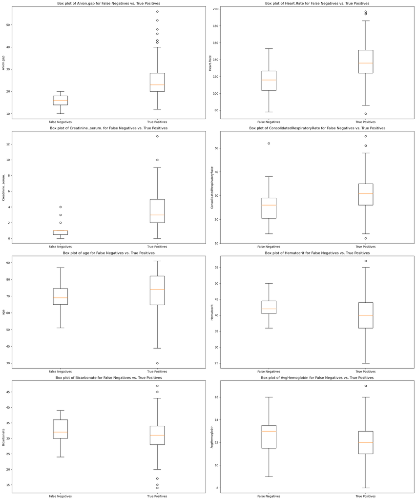

```python
# Determine the number of rows needed
num_rows = len(numerical_features) // 2 + (len(numerical_features) % 2 > 0)

# Create a figure with subplots
fig, axs = plt.subplots(num_rows, 2, figsize=(20, 6*num_rows))

# Plot boxplots for each feature
for i, feature in enumerate(numerical_features):
    row = i // 2
    col = i % 2
    axs[row, col].boxplot([false_negatives[feature].astype(int), true_positives[feature].astype(int)], labels=['False Negatives','True Positives'])
    axs[row, col].set_ylabel(feature)
    axs[row, col].set_title(f'Box plot of {feature} for False Negatives vs. True Positives')

# Adjust layout
plt.tight_layout()
plt.show()
```

Levene's Test

```python
# Initialize an empty list to store p-values
p_values = []

# Calculate Levene's test p-value for each feature
for feature in numerical_features:
    if np.var(true_positives[feature]) == 0 or np.var(false_negatives[feature]) == 0:
        p_values.append({'Feature': feature, 'Levene p-value': 'NA'})
    else:
        levene_test = levene(false_negatives[feature], true_positives[feature])
        p_values.append({'Feature': feature, 'Levene p-value': levene_test.pvalue})

# Create a DataFrame from the list of p-values
p_values_df = pd.DataFrame(p_values)
p_values_df["Levene p-value"] = p_values_df["Levene p-value"].apply(lambda x: f"{x:.6f}" if x != 'NA' else x)
p_values_df
```

|  | Feature | Levene p-value |
| --- | --- | --- |
| 0 | Anion.gap | 0.011274 |
| 1 | Heart.Rate | 0.545469 |
| 2 | Creatinine..serum. | 0.001256 |
| 3 | ConsolidatedRespiratoryRate | 0.936368 |
| 4 | age | 0.105417 |
| 5 | Hematocrit | 0.059450 |
| 6 | Bicarbonate | 0.581598 |
| 7 | AvgHemoglobin | 0.320061 |

According to the Boxplot and Levene's p-value results for each numerical feature comparing the True Positives and False Negatives the Anion.gap, Creatinine..serum. features shows an unequal variance between the two groups. Therefore, we are gonna apply T-test for the equal variance features and Welch T-test for the unequal variance features.

```python
numerical_features_eq = ['Heart.Rate', 'ConsolidatedRespiratoryRate', 'age', 'Hematocrit', 'Bicarbonate', 'AvgHemoglobin']

numerical_features_ueq = ['Anion.gap', 'Creatinine..serum.']
```

Standard T-test

```python
results_false_negatives_eq = []
# Perform t-tests for each numerical feature
for feature in numerical_features_eq:
    false_neg_feature = false_negatives[feature]
    true_pos_feature = true_positives[feature]

    t_stat, p_value = ttest_ind(false_neg_feature, true_pos_feature, equal_var=True)
    results_false_negatives_eq.append([feature, t_stat, p_value])

results_false_negatives_df = pd.DataFrame(results_false_negatives_eq, columns=["Feature", "t-statistic", "p-value"])
# Format p-values
results_false_negatives_df["p-value"] = results_false_negatives_df["p-value"].apply(lambda x: f"{x:.6f}")

results_false_negatives_df
```

|  | Feature | t-statistic | p-value |
| --- | --- | --- | --- |
| 0 | Heart.Rate | -4.111597 | 0.000063 |
| 1 | ConsolidatedRespiratoryRate | -2.494502 | 0.013648 |
| 2 | age | -1.088173 | 0.278186 |
| 3 | Hematocrit | 1.606260 | 0.110226 |
| 4 | Bicarbonate | 1.337958 | 0.182845 |
| 5 | AvgHemoglobin | 1.145596 | 0.253705 |

Welch T-test

```python
results_false_negatives_ueq = []
# Perform t-tests for each numerical feature
for feature in numerical_features_ueq:
    false_neg_feature = false_negatives[feature]
    true_pos_feature = true_positives[feature]

    t_stat, p_value = ttest_ind(false_neg_feature, true_pos_feature, equal_var=False)
    results_false_negatives_ueq.append([feature, t_stat, p_value])

results_false_negatives_df = pd.DataFrame(results_false_negatives_ueq, columns=["Feature", "t-statistic", "p-value"])
# Format p-values
results_false_negatives_df["p-value"] = results_false_negatives_df["p-value"].apply(lambda x: f"{x:.16f}")

results_false_negatives_df
```

|  | Feature | t-statistic | p-value |
| --- | --- | --- | --- |
| 0 | Anion.gap | -10.473268 | 0.0000000000000002 |
| 1 | Creatinine..serum. | -8.170717 | 0.0000000000291926 |

Based on the result, the main factors contributing to false negatives are **Anion.gap, Creatinine..serum., Heart Rate, ConsolidatedRespiratoryRate**.

```python
important_features_fn = ['Anion.gap', 'Creatinine..serum.', 'Heart.Rate', 'ConsolidatedRespiratoryRate']
```

Here, we are gonna create plots comparing the distribution of the selected features between two groups: False negatives and True positives. These plots are useful to understand how the selected features behave differently between false negatives and true positives, which can provide insights into factors contributing to classification errors in the model.

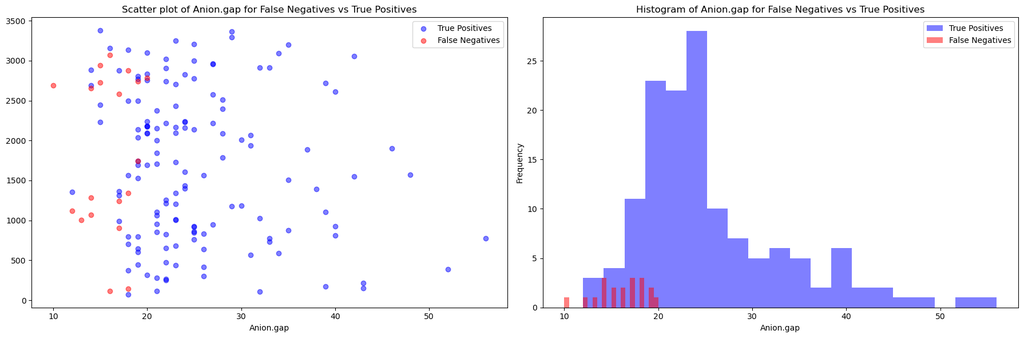

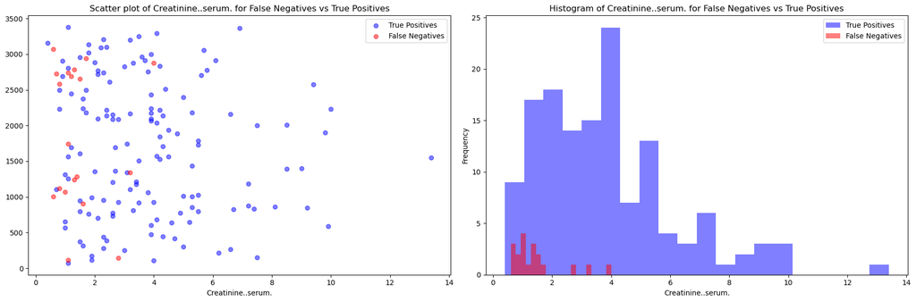

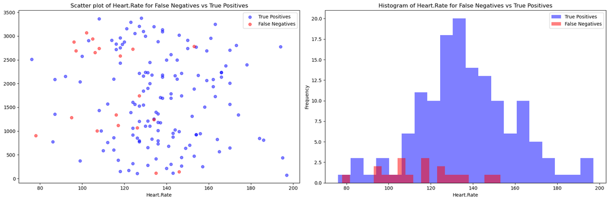

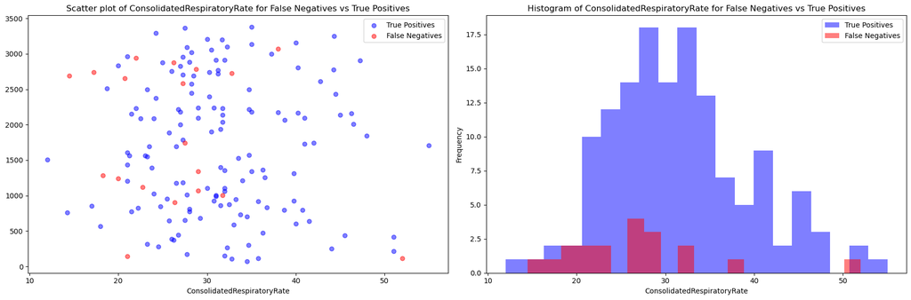

```python
# Display results for each feature in a single row
for feature in important_features_fn:
    # Create a figure with 3 subplots
    fig, axs = plt.subplots(1, 2, figsize=(18, 6))

    # Scatter plot
    axs[0].scatter(true_positives[feature], true_positives.index, c='blue', label='True Positives', alpha=0.5)
    axs[0].scatter(false_negatives[feature],  false_negatives.index, c='red', label='False Negatives', alpha=0.5)
    axs[0].set_xlabel(feature)
    axs[0].set_title(f'Scatter plot of {feature} for False Negatives vs True Positives')
    axs[0].legend()

    # Histogram
    axs[1].hist(true_positives[feature], bins=20, color='blue', alpha=0.5, label='True Positives')
    axs[1].hist(false_negatives[feature], bins=20, color='red', alpha=0.5, label='False Negatives')
    axs[1].set_xlabel(feature)
    axs[1].set_ylabel('Frequency')
    axs[1].set_title(f'Histogram of {feature} for False Negatives vs True Positives')
    axs[1].legend()

    # Adjust layout
    plt.tight_layout()
    plt.show()
```

**Boxplots of numerical variables comparing False Positives and True Negatives**

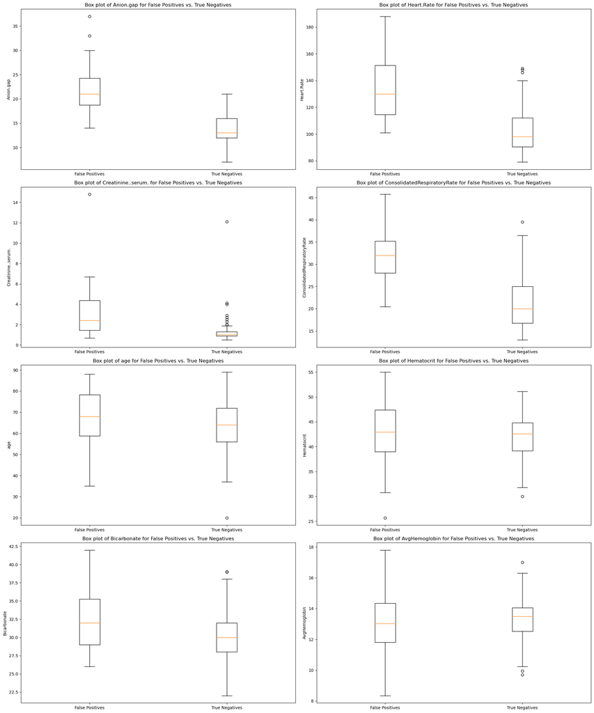

```python
# Determine the number of rows needed
num_rows = len(numerical_features) // 2 + (len(numerical_features) % 2 > 0)

# Create a figure with subplots
fig, axs = plt.subplots(num_rows, 2, figsize=(20, 6*num_rows))

# Plot boxplots for each feature
for i, feature in enumerate(numerical_features):
    row = i // 2
    col = i % 2
    axs[row, col].boxplot([false_positives[feature], true_negatives[feature]], labels=['False Positives', 'True Negatives'])
    axs[row, col].set_ylabel(feature)
    axs[row, col].set_title(f'Box plot of {feature} for False Positives vs. True Negatives')

# Adjust layout
plt.tight_layout()
plt.show()
```

Levene's Test

```python
# Initialize an empty list to store p-values
p_values = []

# Calculate Levene's test p-value for each feature
for feature in numerical_features:
    if np.var(true_negatives[feature]) == 0 or np.var(false_positives[feature]) == 0:
        p_values.append({'Feature': feature, 'Levene p-value': 'NA'})
    else:
        levene_test = levene(false_positives[feature], true_negatives[feature])
        p_values.append({'Feature': feature, 'Levene p-value': levene_test.pvalue})

# Create a DataFrame from the list of p-values
p_values_df = pd.DataFrame(p_values)
p_values_df["Levene p-value"] = p_values_df["Levene p-value"].apply(lambda x: f"{x:.6f}" if x != 'NA' else x)
p_values_df
```

|  | Feature | Levene p-value |
| --- | --- | --- |
| 0 | Anion.gap | 0.005806 |
| 1 | Heart.Rate | 0.015436 |
| 2 | Creatinine..serum. | 0.000000 |
| 3 | ConsolidatedRespiratoryRate | 0.680924 |
| 4 | age | 0.290040 |
| 5 | Hematocrit | 0.000415 |
| 6 | Bicarbonate | 0.028254 |
| 7 | AvgHemoglobin | 0.000078 |

According to the Boxplot and Levene's p-value results for each numerical feature comparing the False Positives and True Negatives the Anion.gap, Heart.Rate, Creatinine..serum., Hematocrit, Bicarbonate, AvgHemoglobin features shows an unequal variance between the two groups. Therefore, we are gonna apply T-test for the equal variance features and Welch T-test for the unequal variance features.

```python
numerical_features_eq = ['ConsolidatedRespiratoryRate', 'age']

numerical_features_ueq = ['Anion.gap', 'Heart.Rate', 'Creatinine..serum.', 'Hematocrit', 'Bicarbonate', 'AvgHemoglobin']
```

Standard T-test

```python
results_false_positives_eq = []
# Perform t-tests for each numerical feature
for feature in numerical_features_eq:
    false_pos_feature = false_positives[feature]
    true_neg_feature = true_negatives[feature]

    t_stat, p_value = ttest_ind(false_pos_feature, true_neg_feature, equal_var=True)
    results_false_positives_eq.append([feature, t_stat, p_value])

results_false_positives_df = pd.DataFrame(results_false_positives_eq, columns=["Feature", "t-statistic", "p-value"])
results_false_positives_df["p-value"] = results_false_positives_df["p-value"].apply(lambda x: f"{x:.6f}")
results_false_positives_df
```

|  | Feature | t-statistic | p-value |
| --- | --- | --- | --- |
| 0 | ConsolidatedRespiratoryRate | 9.724033 | 0.000000 |
| 1 | age | 1.857665 | 0.065090 |

Welch T-test

```python
results_false_positives_ueq = []
# Perform t-tests for each numerical feature
for feature in numerical_features_ueq:
    false_pos_feature = false_positives[feature]
    true_neg_feature = true_negatives[feature]

    t_stat, p_value = ttest_ind(false_pos_feature, true_neg_feature, equal_var=False)
    results_false_positives_ueq.append([feature, t_stat, p_value])

results_false_positives_df = pd.DataFrame(results_false_positives_ueq, columns=["Feature", "t-statistic", "p-value"])
results_false_positives_df["p-value"] = results_false_positives_df["p-value"].apply(lambda x: f"{x:.6f}")
results_false_positives_df
```

|  | Feature | t-statistic | p-value |
| --- | --- | --- | --- |
| 0 | Anion.gap | 9.071381 | 0.000000 |
| 1 | Heart.Rate | 8.542819 | 0.000000 |
| 2 | Creatinine..serum. | 4.521119 | 0.000046 |
| 3 | Hematocrit | 0.618503 | 0.539131 |
| 4 | Bicarbonate | 2.685621 | 0.009495 |
| 5 | AvgHemoglobin | -0.355702 | 0.723654 |

Based on the result, the main factors contributing to false positives are **Anion.gap, Heart.Rate, RespiratoryRate, Creatinine..serum. and Bicarbonate**

```python
important_features_fp = ['Anion.gap', 'Heart.Rate', 'ConsolidatedRespiratoryRate', 'Creatinine..serum.', 'Bicarbonate']
```

Here, we are gonna create plots comparing the distribution of the selected features between two groups: False postives and True negatives. These plots are useful to understand how the selected features behave differently between false positives and true negatives, which can provide insights into factors contributing to classification errors in the model.

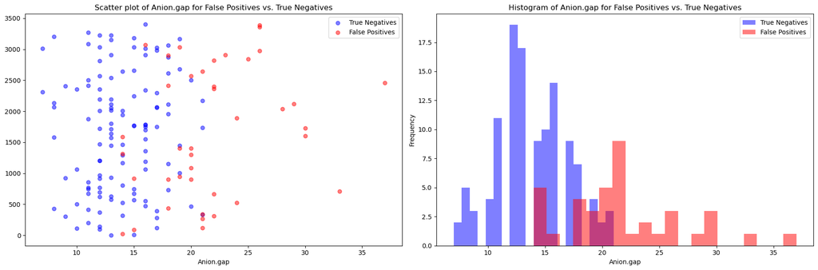

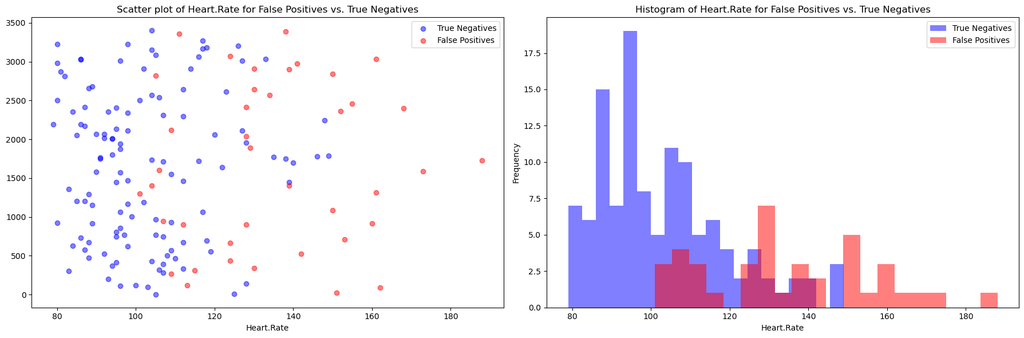

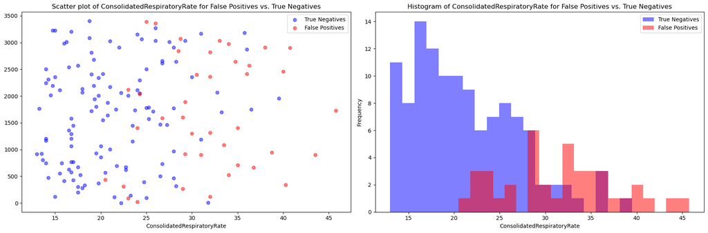

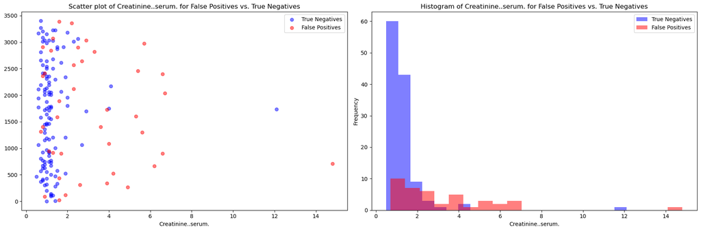

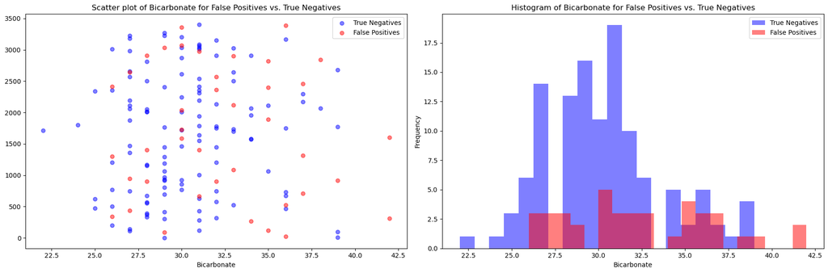

```python
# Display results for each feature in a single row
for feature in important_features_fp:
    # Create a figure with 3 subplots
    fig, axs = plt.subplots(1, 2, figsize=(18, 6))

    # Scatter plot
    axs[0].scatter(true_negatives[feature], true_negatives.index, c='blue', label='True Negatives', alpha=0.5)
    axs[0].scatter(false_positives[feature], false_positives.index, c='red', label='False Positives', alpha=0.5)
    axs[0].set_xlabel(feature)
    axs[0].set_title(f'Scatter plot of {feature} for False Positives vs. True Negatives')
    axs[0].legend()

    # Histogram
    axs[1].hist(true_negatives[feature], bins=20, color='blue', alpha=0.5, label='True Negatives')
    axs[1].hist(false_positives[feature], bins=20, color='red', alpha=0.5, label='False Positives')
    axs[1].set_xlabel(feature)
    axs[1].set_ylabel('Frequency')
    axs[1].set_title(f'Histogram of {feature} for False Positives vs. True Negatives')
    axs[1].legend()

    # Adjust layout
    plt.tight_layout()
    plt.show()
```

Therefore analysing the statistical test results we can conclude that the factors contributing to the,

- False Negatives: Anion.gap, Creatinine..serum., Heart Rate, ConsolidatedRespiratoryRate
- False Positives: Anion.gap, Heart.Rate, ConsolidatedRespiratoryRate, Creatinine..serum. and Bicarbonate

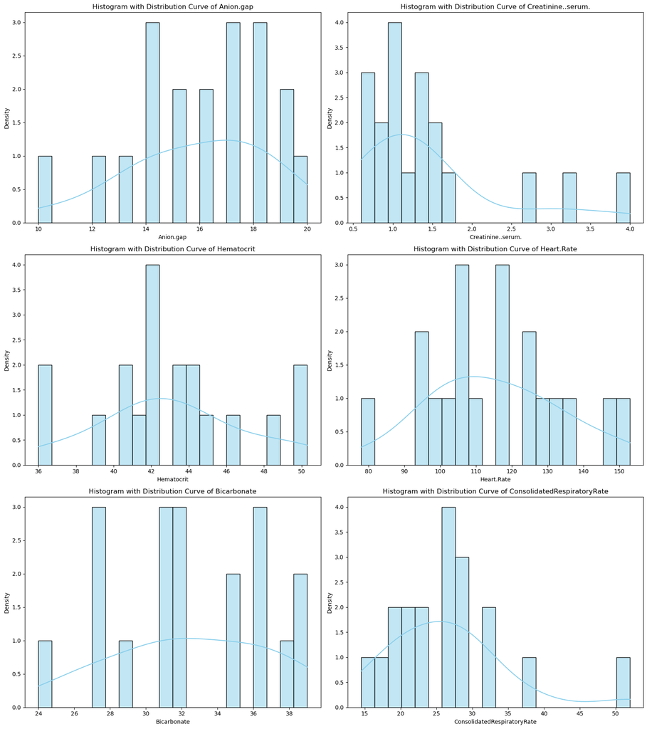

```python
error_prediction_features = ['Anion.gap', 'Creatinine..serum.', 'Hematocrit', 'Heart.Rate', 'Bicarbonate', 'ConsolidatedRespiratoryRate']
num_features = len(error_prediction_features)
num_cols = 2
num_rows = math.ceil(num_features / num_cols)

fig, axs = plt.subplots(num_rows, num_cols, figsize=(16, 6*num_rows))

for i, feature in enumerate(error_prediction_features):
    row = i // num_cols
    col = i % num_cols
    sns.histplot(false_negatives[feature], kde=True, bins=20, color='skyblue', edgecolor='black', ax=axs[row, col])
    axs[row, col].set_xlabel(feature)
    axs[row, col].set_ylabel('Density')
    axs[row, col].set_title(f'Histogram with Distribution Curve of {feature}')

plt.tight_layout()
plt.show()
```